# Risk Factor Analysis

## Outcome Variable

**Outcome Variable:** whz

## Predictor Variables

**Intervention Variable:** sex

**Adjustment Set:**

unadjusted

## Stratifying Variables

The analysis was stratified on these variable(s):

- agecat
- studyid
- country

## Data Summary

| agecat | studyid | country | sex | n_cell | n |
| --- | --- | --- | --- | --- | --- |
| Birth | CMC-V-BCS-2002 | INDIA | Female | 43 | 86 |
| Birth | CMC-V-BCS-2002 | INDIA | Male | 43 | 86 |
| Birth | CMIN | BANGLADESH | Female | 9 | 19 |
| Birth | CMIN | BANGLADESH | Male | 10 | 19 |
| Birth | COHORTS | GUATEMALA | Female | 360 | 756 |
| Birth | COHORTS | GUATEMALA | Male | 396 | 756 |
| Birth | COHORTS | INDIA | Female | 2952 | 6193 |
| Birth | COHORTS | INDIA | Male | 3241 | 6193 |
| Birth | COHORTS | PHILIPPINES | Female | 1360 | 2899 |
| Birth | COHORTS | PHILIPPINES | Male | 1539 | 2899 |
| Birth | CONTENT | PERU | Female | 0 | 2 |
| Birth | CONTENT | PERU | Male | 2 | 2 |
| Birth | EE | PAKISTAN | Female | 88 | 177 |
| Birth | EE | PAKISTAN | Male | 89 | 177 |
| Birth | GMS-Nepal | NEPAL | Female | 297 | 641 |
| Birth | GMS-Nepal | NEPAL | Male | 344 | 641 |
| Birth | IRC | INDIA | Female | 148 | 343 |
| Birth | IRC | INDIA | Male | 195 | 343 |
| Birth | Keneba | GAMBIA | Female | 703 | 1466 |
| Birth | Keneba | GAMBIA | Male | 763 | 1466 |
| Birth | MAL-ED | BANGLADESH | Female | 106 | 215 |
| Birth | MAL-ED | BANGLADESH | Male | 109 | 215 |
| Birth | MAL-ED | BRAZIL | Female | 31 | 62 |
| Birth | MAL-ED | BRAZIL | Male | 31 | 62 |
| Birth | MAL-ED | INDIA | Female | 22 | 45 |
| Birth | MAL-ED | INDIA | Male | 23 | 45 |
| Birth | MAL-ED | NEPAL | Female | 16 | 26 |
| Birth | MAL-ED | NEPAL | Male | 10 | 26 |
| Birth | MAL-ED | PERU | Female | 112 | 228 |
| Birth | MAL-ED | PERU | Male | 116 | 228 |

[output cut: 122 more lines]

The following strata were considered:

- agecat: 24 months, studyid: CMC-V-BCS-2002, country: INDIA
- agecat: 24 months, studyid: CMIN, country: BANGLADESH
- agecat: 24 months, studyid: COHORTS, country: GUATEMALA
- agecat: 24 months, studyid: COHORTS, country: INDIA
- agecat: 24 months, studyid: COHORTS, country: PHILIPPINES
- agecat: 24 months, studyid: CONTENT, country: PERU
- agecat: 24 months, studyid: EE, country: PAKISTAN
- agecat: 24 months, studyid: GMS-Nepal, country: NEPAL
- agecat: 24 months, studyid: IRC, country: INDIA
- agecat: 24 months, studyid: Keneba, country: GAMBIA
- agecat: 24 months, studyid: LCNI-5, country: MALAWI
- agecat: 24 months, studyid: MAL-ED, country: BANGLADESH
- agecat: 24 months, studyid: MAL-ED, country: BRAZIL
- agecat: 24 months, studyid: MAL-ED, country: INDIA
- agecat: 24 months, studyid: MAL-ED, country: NEPAL
- agecat: 24 months, studyid: MAL-ED, country: PERU
- agecat: 24 months, studyid: MAL-ED, country: SOUTH AFRICA
- agecat: 24 months, studyid: MAL-ED, country: TANZANIA, UNITED REPUBLIC OF
- agecat: 24 months, studyid: NIH-Birth, country: BANGLADESH
- agecat: 24 months, studyid: NIH-Crypto, country: BANGLADESH
- agecat: 24 months, studyid: PROBIT, country: BELARUS
- agecat: 24 months, studyid: PROVIDE, country: BANGLADESH
- agecat: 24 months, studyid: TanzaniaChild2, country: TANZANIA, UNITED REPUBLIC OF
- agecat: 24 months, studyid: ZVITAMBO, country: ZIMBABWE
- agecat: 6 months, studyid: CMC-V-BCS-2002, country: INDIA
- agecat: 6 months, studyid: CMIN, country: BANGLADESH
- agecat: 6 months, studyid: COHORTS, country: GUATEMALA
- agecat: 6 months, studyid: COHORTS, country: INDIA
- agecat: 6 months, studyid: COHORTS, country: PHILIPPINES
- agecat: 6 months, studyid: CONTENT, country: PERU
- agecat: 6 months, studyid: EE, country: PAKISTAN
- agecat: 6 months, studyid: GMS-Nepal, country: NEPAL
- agecat: 6 months, studyid: Guatemala BSC, country: GUATEMALA
- agecat: 6 months, studyid: IRC, country: INDIA
- agecat: 6 months, studyid: Keneba, country: GAMBIA
- agecat: 6 months, studyid: LCNI-5, country: MALAWI
- agecat: 6 months, studyid: MAL-ED, country: BANGLADESH
- agecat: 6 months, studyid: MAL-ED, country: BRAZIL
- agecat: 6 months, studyid: MAL-ED, country: INDIA
- agecat: 6 months, studyid: MAL-ED, country: NEPAL
- agecat: 6 months, studyid: MAL-ED, country: PERU
- agecat: 6 months, studyid: MAL-ED, country: SOUTH AFRICA
- agecat: 6 months, studyid: MAL-ED, country: TANZANIA, UNITED REPUBLIC OF
- agecat: 6 months, studyid: NIH-Birth, country: BANGLADESH
- agecat: 6 months, studyid: NIH-Crypto, country: BANGLADESH
- agecat: 6 months, studyid: PROBIT, country: BELARUS
- agecat: 6 months, studyid: PROVIDE, country: BANGLADESH
- agecat: 6 months, studyid: ResPak, country: PAKISTAN
- agecat: 6 months, studyid: SAS-CompFeed, country: INDIA
- agecat: 6 months, studyid: SAS-FoodSuppl, country: INDIA
- agecat: 6 months, studyid: TanzaniaChild2, country: TANZANIA, UNITED REPUBLIC OF
- agecat: 6 months, studyid: ZVITAMBO, country: ZIMBABWE
- agecat: Birth, studyid: CMC-V-BCS-2002, country: INDIA
- agecat: Birth, studyid: CMIN, country: BANGLADESH
- agecat: Birth, studyid: COHORTS, country: GUATEMALA
- agecat: Birth, studyid: COHORTS, country: INDIA
- agecat: Birth, studyid: COHORTS, country: PHILIPPINES
- agecat: Birth, studyid: CONTENT, country: PERU
- agecat: Birth, studyid: EE, country: PAKISTAN
- agecat: Birth, studyid: GMS-Nepal, country: NEPAL
- agecat: Birth, studyid: IRC, country: INDIA
- agecat: Birth, studyid: Keneba, country: GAMBIA
- agecat: Birth, studyid: MAL-ED, country: BANGLADESH
- agecat: Birth, studyid: MAL-ED, country: BRAZIL
- agecat: Birth, studyid: MAL-ED, country: INDIA
- agecat: Birth, studyid: MAL-ED, country: NEPAL
- agecat: Birth, studyid: MAL-ED, country: PERU
- agecat: Birth, studyid: MAL-ED, country: SOUTH AFRICA
- agecat: Birth, studyid: MAL-ED, country: TANZANIA, UNITED REPUBLIC OF
- agecat: Birth, studyid: NIH-Birth, country: BANGLADESH
- agecat: Birth, studyid: NIH-Crypto, country: BANGLADESH
- agecat: Birth, studyid: PROBIT, country: BELARUS
- agecat: Birth, studyid: PROVIDE, country: BANGLADESH
- agecat: Birth, studyid: ResPak, country: PAKISTAN
- agecat: Birth, studyid: SAS-CompFeed, country: INDIA
- agecat: Birth, studyid: ZVITAMBO, country: ZIMBABWE

### Dropped Strata

Some strata were dropped due to rare outcomes:

- agecat: Birth, studyid: CONTENT, country: PERU
- agecat: 24 months, studyid: TanzaniaChild2, country: TANZANIA, UNITED REPUBLIC OF

## Methods Detail

We’re interested in the causal parameters $E[Y_a]$ for all values of $a \in \mathcal{A}$. These parameters represent the mean outcome if, possibly contrary to fact, we intervened to set all units to have $A=a$. Under the randomization and positivity assumptions, these are identified by the statistical parameters $\psi_a=E_W[E_{Y|A,W}(Y|A=a,W)]$. In addition, we’re interested in the mean of $Y$, $E[Y]$ under no intervention (the observed mean). We will estimate these parameters by using SuperLearner to fit the relevant likelihood factors – $E_{Y|A,W}(Y|A=a,W)$ and $p(A=a|W)$, and then updating our likelihood fit using a joint TMLE.

For unadjusted analyses ($W=\{\}$), initial likelihoods were estimated using Lrnr_glm to estimate the simple $E(Y|A)$ and Lrnr_mean to estimate $p(A)$. For adjusted analyses, a small library containing Lrnr_glmnet, Lrnr_xgboost, and Lrnr_mean was used.

Having estimated these parameters, we will then use the delta method to estimate relative risks and attributable risks relative to a prespecified baseline level of $A$.

# Results Detail

## Results Plots

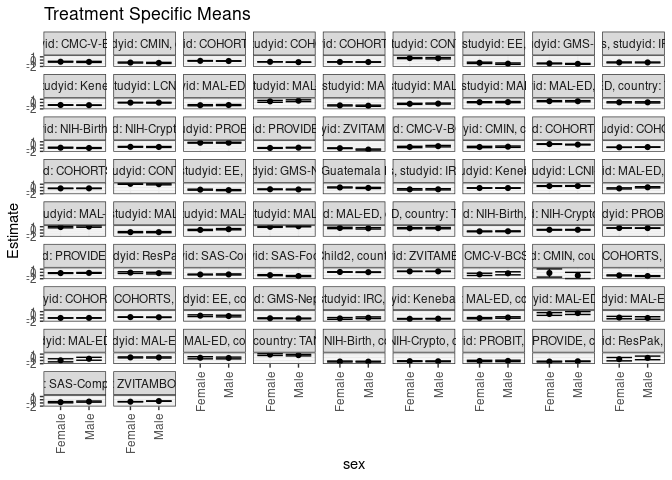

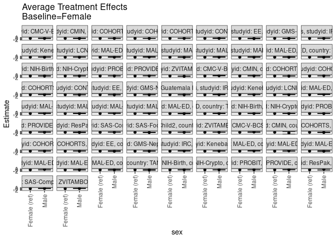

[figure not shown]

## Results Table

### Parameter: TSM

| agecat | studyid | country | intervention_level | baseline_level | estimate | ci_lower | ci_upper |
| --- | --- | --- | --- | --- | --- | --- | --- |
| Birth | CMC-V-BCS-2002 | INDIA | Female | NA | -0.6309302 | -0.9903846 | -0.2714758 |
| Birth | CMC-V-BCS-2002 | INDIA | Male | NA | -0.2987209 | -0.7726353 | 0.1751934 |
| Birth | CMIN | BANGLADESH | Female | NA | -0.1988889 | -1.4822688 | 1.0844910 |
| Birth | CMIN | BANGLADESH | Male | NA | -0.9760000 | -1.9451649 | -0.0068351 |
| Birth | COHORTS | GUATEMALA | Female | NA | -0.9511111 | -1.0951183 | -0.8071040 |
| Birth | COHORTS | GUATEMALA | Male | NA | -1.1630808 | -1.3038964 | -1.0222652 |
| Birth | COHORTS | INDIA | Female | NA | -0.9916497 | -1.0350141 | -0.9482853 |
| Birth | COHORTS | INDIA | Male | NA | -0.9784573 | -1.0194329 | -0.9374816 |
| Birth | COHORTS | PHILIPPINES | Female | NA | -0.7172941 | -0.7849402 | -0.6496480 |
| Birth | COHORTS | PHILIPPINES | Male | NA | -0.7651982 | -0.8288391 | -0.7015573 |
| Birth | EE | PAKISTAN | Female | NA | -0.2737500 | -0.5386067 | -0.0088933 |
| Birth | EE | PAKISTAN | Male | NA | -0.3921910 | -0.6575616 | -0.1268205 |
| Birth | GMS-Nepal | NEPAL | Female | NA | -1.0841414 | -1.2209753 | -0.9473075 |
| Birth | GMS-Nepal | NEPAL | Male | NA | -1.1443314 | -1.2568078 | -1.0318550 |
| Birth | IRC | INDIA | Female | NA | -1.1279054 | -1.3974695 | -0.8583413 |
| Birth | IRC | INDIA | Male | NA | -0.9215385 | -1.1777563 | -0.6653206 |
| Birth | Keneba | GAMBIA | Female | NA | -1.2574324 | -1.3480400 | -1.1668249 |
| Birth | Keneba | GAMBIA | Male | NA | -1.2142267 | -1.2999739 | -1.1284796 |
| Birth | MAL-ED | BANGLADESH | Female | NA | -1.0441981 | -1.2307197 | -0.8576765 |
| Birth | MAL-ED | BANGLADESH | Male | NA | -0.8423394 | -1.0621738 | -0.6225051 |
| Birth | MAL-ED | BRAZIL | Female | NA | 0.2561290 | -0.1785444 | 0.6908025 |
| Birth | MAL-ED | BRAZIL | Male | NA | 0.5496774 | 0.1046276 | 0.9947272 |
| Birth | MAL-ED | INDIA | Female | NA | -0.8672727 | -1.2477961 | -0.4867494 |
| Birth | MAL-ED | INDIA | Male | NA | -0.9947826 | -1.3875646 | -0.6020006 |
| Birth | MAL-ED | NEPAL | Female | NA | -0.9550000 | -1.4371892 | -0.4728108 |
| Birth | MAL-ED | NEPAL | Male | NA | -0.4700000 | -0.9282917 | -0.0117083 |
| Birth | MAL-ED | PERU | Female | NA | -0.0438393 | -0.2000688 | 0.1123902 |
| Birth | MAL-ED | PERU | Male | NA | -0.0599138 | -0.2425315 | 0.1227039 |
| Birth | MAL-ED | SOUTH AFRICA | Female | NA | -0.1551786 | -0.4835647 | 0.1732076 |
| Birth | MAL-ED | SOUTH AFRICA | Male | NA | -0.2253125 | -0.5018259 | 0.0512009 |

[output cut: 118 more lines]

### Parameter: E(Y)

| agecat | studyid | country | intervention_level | baseline_level | estimate | ci_lower | ci_upper |
| --- | --- | --- | --- | --- | --- | --- | --- |
| Birth | CMC-V-BCS-2002 | INDIA | NA | NA | -0.4648256 | -0.7643210 | -0.1653302 |
| Birth | CMIN | BANGLADESH | NA | NA | -0.6078947 | -1.4214563 | 0.2056668 |
| Birth | COHORTS | GUATEMALA | NA | NA | -1.0621429 | -1.1631387 | -0.9611471 |
| Birth | COHORTS | INDIA | NA | NA | -0.9847457 | -1.0145305 | -0.9549609 |
| Birth | COHORTS | PHILIPPINES | NA | NA | -0.7427251 | -0.7890855 | -0.6963647 |
| Birth | EE | PAKISTAN | NA | NA | -0.3333051 | -0.5209779 | -0.1456323 |
| Birth | GMS-Nepal | NEPAL | NA | NA | -1.1164431 | -1.2040134 | -1.0288728 |
| Birth | IRC | INDIA | NA | NA | -1.0105831 | -1.1973019 | -0.8238643 |
| Birth | Keneba | GAMBIA | NA | NA | -1.2349454 | -1.2972413 | -1.1726496 |
| Birth | MAL-ED | BANGLADESH | NA | NA | -0.9418605 | -1.0869834 | -0.7967375 |
| Birth | MAL-ED | BRAZIL | NA | NA | 0.4029032 | 0.0896793 | 0.7161272 |
| Birth | MAL-ED | INDIA | NA | NA | -0.9324444 | -1.2067907 | -0.6580982 |
| Birth | MAL-ED | NEPAL | NA | NA | -0.7684615 | -1.1257770 | -0.4111460 |
| Birth | MAL-ED | PERU | NA | NA | -0.0520175 | -0.1725298 | 0.0684947 |
| Birth | MAL-ED | SOUTH AFRICA | NA | NA | -0.1925833 | -0.4053570 | 0.0201904 |
| Birth | MAL-ED | TANZANIA, UNITED REPUBLIC OF | NA | NA | 0.7624348 | 0.5710709 | 0.9537986 |
| Birth | NIH-Birth | BANGLADESH | NA | NA | -1.3499217 | -1.4444634 | -1.2553801 |
| Birth | NIH-Crypto | BANGLADESH | NA | NA | -1.2441513 | -1.3281130 | -1.1601897 |
| Birth | PROBIT | BELARUS | NA | NA | -1.1491782 | -1.3593933 | -0.9389630 |
| Birth | PROVIDE | BANGLADESH | NA | NA | -1.2984586 | -1.3752758 | -1.2216415 |
| Birth | ResPak | PAKISTAN | NA | NA | -0.3663158 | -0.7677415 | 0.0351099 |
| Birth | SAS-CompFeed | INDIA | NA | NA | -0.6700453 | -0.8474950 | -0.4925957 |
| Birth | ZVITAMBO | ZIMBABWE | NA | NA | -0.5154897 | -0.5413479 | -0.4896314 |
| 6 months | CMC-V-BCS-2002 | INDIA | NA | NA | -0.5026766 | -0.6536848 | -0.3516685 |
| 6 months | CMIN | BANGLADESH | NA | NA | -0.5780453 | -0.7226627 | -0.4334279 |
| 6 months | COHORTS | GUATEMALA | NA | NA | 0.1940810 | 0.1226351 | 0.2655269 |
| 6 months | COHORTS | INDIA | NA | NA | -0.6908803 | -0.7184601 | -0.6633005 |
| 6 months | COHORTS | PHILIPPINES | NA | NA | -0.2938433 | -0.3352064 | -0.2524802 |
| 6 months | CONTENT | PERU | NA | NA | 1.0644279 | 0.9468682 | 1.1819876 |
| 6 months | EE | PAKISTAN | NA | NA | -0.7747022 | -0.8887874 | -0.6606170 |
| 6 months | GMS-Nepal | NEPAL | NA | NA | -0.6038416 | -0.6899448 | -0.5177384 |
| 6 months | Guatemala BSC | GUATEMALA | NA | NA | -0.0840134 | -0.1945572 | 0.0265305 |
| 6 months | IRC | INDIA | NA | NA | -0.5989297 | -0.7344491 | -0.4634104 |
| 6 months | Keneba | GAMBIA | NA | NA | -0.1846038 | -0.2354782 | -0.1337293 |
| 6 months | LCNI-5 | MALAWI | NA | NA | 0.4499404 | 0.3788501 | 0.5210308 |
| 6 months | MAL-ED | BANGLADESH | NA | NA | -0.1376763 | -0.2664642 | -0.0088885 |
| 6 months | MAL-ED | BRAZIL | NA | NA | 0.9720774 | 0.8078144 | 1.1363403 |
| 6 months | MAL-ED | INDIA | NA | NA | -0.7079979 | -0.8344175 | -0.5815783 |
| 6 months | MAL-ED | NEPAL | NA | NA | 0.1104308 | -0.0208643 | 0.2417259 |
| 6 months | MAL-ED | PERU | NA | NA | 1.0528816 | 0.9313005 | 1.1744626 |
| 6 months | MAL-ED | SOUTH AFRICA | NA | NA | 0.5421785 | 0.3900443 | 0.6943126 |
| 6 months | MAL-ED | TANZANIA, UNITED REPUBLIC OF | NA | NA | 0.5362213 | 0.4049390 | 0.6675036 |
| 6 months | NIH-Birth | BANGLADESH | NA | NA | -0.4474038 | -0.5378167 | -0.3569909 |
| 6 months | NIH-Crypto | BANGLADESH | NA | NA | 0.0297622 | -0.0491685 | 0.1086930 |
| 6 months | PROBIT | BELARUS | NA | NA | 0.5741099 | 0.5141290 | 0.6340908 |
| 6 months | PROVIDE | BANGLADESH | NA | NA | -0.1990907 | -0.2817968 | -0.1163845 |
| 6 months | ResPak | PAKISTAN | NA | NA | -0.1641841 | -0.3464247 | 0.0180565 |
| 6 months | SAS-CompFeed | INDIA | NA | NA | -0.6657084 | -0.8024377 | -0.5289791 |
| 6 months | SAS-FoodSuppl | INDIA | NA | NA | -1.0121579 | -1.1280429 | -0.8962729 |
| 6 months | TanzaniaChild2 | TANZANIA, UNITED REPUBLIC OF | NA | NA | 0.0809332 | 0.0282644 | 0.1336020 |
| 6 months | ZVITAMBO | ZIMBABWE | NA | NA | 0.3105514 | 0.2848767 | 0.3362262 |
| 24 months | CMC-V-BCS-2002 | INDIA | NA | NA | -0.5571505 | -0.6585247 | -0.4557763 |
| 24 months | CMIN | BANGLADESH | NA | NA | -0.8535391 | -0.9644236 | -0.7426546 |
| 24 months | COHORTS | GUATEMALA | NA | NA | -0.2815804 | -0.3354498 | -0.2277110 |
| 24 months | COHORTS | INDIA | NA | NA | -0.6073238 | -0.6354743 | -0.5791732 |
| 24 months | COHORTS | PHILIPPINES | NA | NA | -0.6099592 | -0.6467541 | -0.5731643 |
| 24 months | CONTENT | PERU | NA | NA | 0.5902439 | 0.4560143 | 0.7244735 |
| 24 months | EE | PAKISTAN | NA | NA | -1.0120238 | -1.1588493 | -0.8651984 |
| 24 months | GMS-Nepal | NEPAL | NA | NA | -1.1363107 | -1.2252817 | -1.0473398 |
| 24 months | IRC | INDIA | NA | NA | -0.7458150 | -0.8368180 | -0.6548120 |
| 24 months | Keneba | GAMBIA | NA | NA | -0.8099290 | -0.8570608 | -0.7627972 |
| 24 months | LCNI-5 | MALAWI | NA | NA | -0.0477709 | -0.1296526 | 0.0341109 |
| 24 months | MAL-ED | BANGLADESH | NA | NA | -0.8192925 | -0.9412667 | -0.6973182 |
| 24 months | MAL-ED | BRAZIL | NA | NA | 0.4626233 | 0.2567495 | 0.6684971 |
| 24 months | MAL-ED | INDIA | NA | NA | -0.9516520 | -1.0670654 | -0.8362385 |
| 24 months | MAL-ED | NEPAL | NA | NA | -0.3749123 | -0.4886073 | -0.2612173 |
| 24 months | MAL-ED | PERU | NA | NA | 0.1111982 | -0.0118399 | 0.2342362 |
| 24 months | MAL-ED | SOUTH AFRICA | NA | NA | 0.4090301 | 0.2879441 | 0.5301161 |
| 24 months | MAL-ED | TANZANIA, UNITED REPUBLIC OF | NA | NA | 0.0547975 | -0.0703378 | 0.1799328 |
| 24 months | NIH-Birth | BANGLADESH | NA | NA | -0.9115790 | -1.0095022 | -0.8136559 |
| 24 months | NIH-Crypto | BANGLADESH | NA | NA | -0.6103502 | -0.7050157 | -0.5156847 |
| 24 months | PROBIT | BELARUS | NA | NA | 0.6981406 | 0.5843775 | 0.8119038 |
| 24 months | PROVIDE | BANGLADESH | NA | NA | -0.8928670 | -0.9755153 | -0.8102187 |
| 24 months | ZVITAMBO | ZIMBABWE | NA | NA | -1.1825404 | -1.2814625 | -1.0836183 |

### Parameter: ATE

| agecat | studyid | country | intervention_level | baseline_level | estimate | ci_lower | ci_upper |
| --- | --- | --- | --- | --- | --- | --- | --- |
| Birth | CMC-V-BCS-2002 | INDIA | Female | Female | 0.0000000 | 0.0000000 | 0.0000000 |
| Birth | CMC-V-BCS-2002 | INDIA | Male | Female | 0.3322093 | -0.2626035 | 0.9270221 |
| Birth | CMIN | BANGLADESH | Female | Female | 0.0000000 | 0.0000000 | 0.0000000 |
| Birth | CMIN | BANGLADESH | Male | Female | -0.7771111 | -2.3853227 | 0.8311005 |
| Birth | COHORTS | GUATEMALA | Female | Female | 0.0000000 | 0.0000000 | 0.0000000 |
| Birth | COHORTS | GUATEMALA | Male | Female | -0.2119697 | -0.4133825 | -0.0105569 |
| Birth | COHORTS | INDIA | Female | Female | 0.0000000 | 0.0000000 | 0.0000000 |
| Birth | COHORTS | INDIA | Male | Female | 0.0131925 | -0.0464689 | 0.0728538 |
| Birth | COHORTS | PHILIPPINES | Female | Female | 0.0000000 | 0.0000000 | 0.0000000 |
| Birth | COHORTS | PHILIPPINES | Male | Female | -0.0479041 | -0.1407812 | 0.0449731 |
| Birth | EE | PAKISTAN | Female | Female | 0.0000000 | 0.0000000 | 0.0000000 |
| Birth | EE | PAKISTAN | Male | Female | -0.1184410 | -0.4933685 | 0.2564865 |
| Birth | GMS-Nepal | NEPAL | Female | Female | 0.0000000 | 0.0000000 | 0.0000000 |
| Birth | GMS-Nepal | NEPAL | Male | Female | -0.0601900 | -0.2373183 | 0.1169383 |
| Birth | IRC | INDIA | Female | Female | 0.0000000 | 0.0000000 | 0.0000000 |
| Birth | IRC | INDIA | Male | Female | 0.2063669 | -0.1655368 | 0.5782707 |
| Birth | Keneba | GAMBIA | Female | Female | 0.0000000 | 0.0000000 | 0.0000000 |
| Birth | Keneba | GAMBIA | Male | Female | 0.0432057 | -0.0815433 | 0.1679547 |
| Birth | MAL-ED | BANGLADESH | Female | Female | 0.0000000 | 0.0000000 | 0.0000000 |
| Birth | MAL-ED | BANGLADESH | Male | Female | 0.2018587 | -0.0864423 | 0.4901597 |
| Birth | MAL-ED | BRAZIL | Female | Female | 0.0000000 | 0.0000000 | 0.0000000 |
| Birth | MAL-ED | BRAZIL | Male | Female | 0.2935484 | -0.3285532 | 0.9156499 |
| Birth | MAL-ED | INDIA | Female | Female | 0.0000000 | 0.0000000 | 0.0000000 |
| Birth | MAL-ED | INDIA | Male | Female | -0.1275099 | -0.6743880 | 0.4193683 |
| Birth | MAL-ED | NEPAL | Female | Female | 0.0000000 | 0.0000000 | 0.0000000 |
| Birth | MAL-ED | NEPAL | Male | Female | 0.4850000 | -0.1802351 | 1.1502351 |
| Birth | MAL-ED | PERU | Female | Female | 0.0000000 | 0.0000000 | 0.0000000 |
| Birth | MAL-ED | PERU | Male | Female | -0.0160745 | -0.2564011 | 0.2242521 |
| Birth | MAL-ED | SOUTH AFRICA | Female | Female | 0.0000000 | 0.0000000 | 0.0000000 |
| Birth | MAL-ED | SOUTH AFRICA | Male | Female | -0.0701339 | -0.4994323 | 0.3591644 |

[output cut: 118 more lines]

### Parameter: PAR

| agecat | studyid | country | intervention_level | baseline_level | estimate | ci_lower | ci_upper |
| --- | --- | --- | --- | --- | --- | --- | --- |
| Birth | CMC-V-BCS-2002 | INDIA | Female | NA | 0.1661047 | -0.1333908 | 0.4656001 |
| Birth | CMIN | BANGLADESH | Female | NA | -0.4090058 | -1.2742052 | 0.4561935 |
| Birth | COHORTS | GUATEMALA | Female | NA | -0.1110317 | -0.2168036 | -0.0052599 |
| Birth | COHORTS | INDIA | Female | NA | 0.0069040 | -0.0243191 | 0.0381272 |
| Birth | COHORTS | PHILIPPINES | Female | NA | -0.0254310 | -0.0747446 | 0.0238827 |
| Birth | EE | PAKISTAN | Female | NA | -0.0595551 | -0.2482808 | 0.1291707 |
| Birth | GMS-Nepal | NEPAL | Female | NA | -0.0323016 | -0.1273880 | 0.0627847 |
| Birth | IRC | INDIA | Female | NA | 0.1173223 | -0.0943872 | 0.3290318 |
| Birth | Keneba | GAMBIA | Female | NA | 0.0224870 | -0.0424497 | 0.0874237 |
| Birth | MAL-ED | BANGLADESH | Female | NA | 0.1023376 | -0.0444483 | 0.2491236 |
| Birth | MAL-ED | BRAZIL | Female | NA | 0.1467742 | -0.1664497 | 0.4599981 |
| Birth | MAL-ED | INDIA | Female | NA | -0.0651717 | -0.3453210 | 0.2149776 |
| Birth | MAL-ED | NEPAL | Female | NA | 0.1865385 | -0.0855259 | 0.4586028 |
| Birth | MAL-ED | PERU | Female | NA | -0.0081783 | -0.1304542 | 0.1140976 |
| Birth | MAL-ED | SOUTH AFRICA | Female | NA | -0.0374048 | -0.2664502 | 0.1916407 |
| Birth | MAL-ED | TANZANIA, UNITED REPUBLIC OF | Female | NA | -0.0797874 | -0.2496165 | 0.0900416 |
| Birth | NIH-Birth | BANGLADESH | Female | NA | -0.0182861 | -0.1195127 | 0.0829406 |
| Birth | NIH-Crypto | BANGLADESH | Female | NA | -0.0153942 | -0.1002267 | 0.0694382 |
| Birth | PROBIT | BELARUS | Female | NA | 0.0101230 | -0.0113761 | 0.0316221 |
| Birth | PROVIDE | BANGLADESH | Female | NA | 0.0448083 | -0.0366770 | 0.1262936 |
| Birth | ResPak | PAKISTAN | Female | NA | 0.2311842 | -0.2215546 | 0.6839231 |
| Birth | SAS-CompFeed | INDIA | Female | NA | 0.1012625 | 0.0493504 | 0.1531746 |
| Birth | ZVITAMBO | ZIMBABWE | Female | NA | 0.1001805 | 0.0733764 | 0.1269847 |
| 6 months | CMC-V-BCS-2002 | INDIA | Female | NA | 0.1221262 | -0.0274060 | 0.2716585 |
| 6 months | CMIN | BANGLADESH | Female | NA | 0.0512563 | -0.1112360 | 0.2137487 |
| 6 months | COHORTS | GUATEMALA | Female | NA | -0.0887260 | -0.1633611 | -0.0140909 |
| 6 months | COHORTS | INDIA | Female | NA | 0.0337056 | 0.0049962 | 0.0624150 |
| 6 months | COHORTS | PHILIPPINES | Female | NA | 0.0074665 | -0.0360670 | 0.0510000 |
| 6 months | CONTENT | PERU | Female | NA | -0.0586638 | -0.1750155 | 0.0576878 |
| 6 months | EE | PAKISTAN | Female | NA | -0.0746747 | -0.1919188 | 0.0425693 |
| 6 months | GMS-Nepal | NEPAL | Female | NA | -0.0311249 | -0.1195555 | 0.0573058 |
| 6 months | Guatemala BSC | GUATEMALA | Female | NA | -0.0737955 | -0.1821490 | 0.0345579 |
| 6 months | IRC | INDIA | Female | NA | 0.0112695 | -0.1378296 | 0.1603687 |
| 6 months | Keneba | GAMBIA | Female | NA | -0.0061323 | -0.0584690 | 0.0462045 |
| 6 months | LCNI-5 | MALAWI | Female | NA | 0.0126071 | -0.0584045 | 0.0836187 |
| 6 months | MAL-ED | BANGLADESH | Female | NA | 0.1655757 | 0.0392321 | 0.2919193 |
| 6 months | MAL-ED | BRAZIL | Female | NA | 0.0846987 | -0.0820118 | 0.2514093 |
| 6 months | MAL-ED | INDIA | Female | NA | 0.0016367 | -0.1117252 | 0.1149987 |
| 6 months | MAL-ED | NEPAL | Female | NA | 0.1204611 | -0.0187806 | 0.2597028 |
| 6 months | MAL-ED | PERU | Female | NA | 0.1051567 | -0.0243133 | 0.2346267 |
| 6 months | MAL-ED | SOUTH AFRICA | Female | NA | -0.0588930 | -0.2121320 | 0.0943461 |
| 6 months | MAL-ED | TANZANIA, UNITED REPUBLIC OF | Female | NA | 0.0088668 | -0.1198941 | 0.1376277 |
| 6 months | NIH-Birth | BANGLADESH | Female | NA | 0.0154874 | -0.0822151 | 0.1131899 |
| 6 months | NIH-Crypto | BANGLADESH | Female | NA | 0.0002871 | -0.0777426 | 0.0783168 |
| 6 months | PROBIT | BELARUS | Female | NA | -0.0159012 | -0.0349800 | 0.0031775 |
| 6 months | PROVIDE | BANGLADESH | Female | NA | 0.0303711 | -0.0556970 | 0.1164393 |
| 6 months | ResPak | PAKISTAN | Female | NA | -0.0844015 | -0.2733924 | 0.1045894 |
| 6 months | SAS-CompFeed | INDIA | Female | NA | 0.0168900 | -0.0354875 | 0.0692674 |
| 6 months | SAS-FoodSuppl | INDIA | Female | NA | -0.1363658 | -0.2455361 | -0.0271955 |
| 6 months | TanzaniaChild2 | TANZANIA, UNITED REPUBLIC OF | Female | NA | -0.0289721 | -0.0821489 | 0.0242047 |
| 6 months | ZVITAMBO | ZIMBABWE | Female | NA | -0.0017531 | -0.0280431 | 0.0245369 |
| 24 months | CMC-V-BCS-2002 | INDIA | Female | NA | -0.0257885 | -0.1271627 | 0.0755857 |
| 24 months | CMIN | BANGLADESH | Female | NA | -0.0615199 | -0.1856592 | 0.0626194 |
| 24 months | COHORTS | GUATEMALA | Female | NA | -0.0262703 | -0.0827254 | 0.0301847 |
| 24 months | COHORTS | INDIA | Female | NA | -0.0541544 | -0.0835518 | -0.0247570 |
| 24 months | COHORTS | PHILIPPINES | Female | NA | -0.0138365 | -0.0524988 | 0.0248257 |
| 24 months | CONTENT | PERU | Female | NA | -0.0195709 | -0.1550495 | 0.1159077 |
| 24 months | EE | PAKISTAN | Female | NA | -0.1392113 | -0.2922948 | 0.0138722 |
| 24 months | GMS-Nepal | NEPAL | Female | NA | -0.0779554 | -0.1724703 | 0.0165595 |
| 24 months | IRC | INDIA | Female | NA | -0.0055177 | -0.1051774 | 0.0941420 |
| 24 months | Keneba | GAMBIA | Female | NA | -0.0250846 | -0.0743473 | 0.0241780 |
| 24 months | LCNI-5 | MALAWI | Female | NA | -0.0070891 | -0.0877925 | 0.0736144 |
| 24 months | MAL-ED | BANGLADESH | Female | NA | 0.0283518 | -0.0959659 | 0.1526695 |
| 24 months | MAL-ED | BRAZIL | Female | NA | 0.1050072 | -0.1141490 | 0.3241635 |
| 24 months | MAL-ED | INDIA | Female | NA | -0.0473487 | -0.1546300 | 0.0599326 |
| 24 months | MAL-ED | NEPAL | Female | NA | 0.0353707 | -0.0862524 | 0.1569938 |
| 24 months | MAL-ED | PERU | Female | NA | 0.0131945 | -0.1178773 | 0.1442663 |
| 24 months | MAL-ED | SOUTH AFRICA | Female | NA | -0.0144445 | -0.1364327 | 0.1075437 |
| 24 months | MAL-ED | TANZANIA, UNITED REPUBLIC OF | Female | NA | -0.0053912 | -0.1315587 | 0.1207764 |
| 24 months | NIH-Birth | BANGLADESH | Female | NA | -0.0469850 | -0.1538520 | 0.0598820 |
| 24 months | NIH-Crypto | BANGLADESH | Female | NA | -0.0152733 | -0.1090208 | 0.0784743 |
| 24 months | PROBIT | BELARUS | Female | NA | 0.0077242 | -0.0529748 | 0.0684231 |
| 24 months | PROVIDE | BANGLADESH | Female | NA | 0.0495703 | -0.0359370 | 0.1350775 |
| 24 months | ZVITAMBO | ZIMBABWE | Female | NA | -0.1679016 | -0.2503378 | -0.0854655 |